# Analysis of Median Income and Population of Residents Born in the Same State in Roanoke, VA

Henry Hurt

## Introduction

An exploratory analysis of the 2010 US census date for Virginia revealed a close correlation between the percentage of a locale’s population that was born in the same state and the median income of its population. This analysis sought to describe this correlation as it relates to geographic distribution among urban and rural areas in the core-based statistical area of Roanoke, VA. Within the Roanoke region, this analysis also found that locales in urban areas had the lowest median incomes in the region and yet had the highest population of working-age residents.

## Virginia Trends

When the percentage of a locale’s population that was born in the same state is compared to the median income of the same locale, a well defined correlation emerges. A graph comparing these variables shows that the locales with in-state populations in VA between approximately 18 and 45 percent have a maximum range of median incomes of 250,000 per year and have a tendency to be broadly spread out along this full range of incomes. As the percentage of the in-state population increases or decreases, the median income falls sharply. In locales with a higher in-state population of approximately 50 percent and above, there is an indirect correlation between a locales’ in-state population and median income. No locales with an in-state population above 75 percent had a median annual income greater than 100,000$. There was also a slight trend for the locales with high in-state populations to have smaller total populations. As income decreased, the concentration of locales with populations in the lowest grouping category, between 507 and 2,890 residents, increased in concentration. This trend was exemplified in the three locales with the highest in-state population, which also have some of the lowest incomes in VA as well as being in the smallest population group. Roanoke, marked here in black, appears to hold with these general trends in VA. All but one of the locales within the Roanoke region have an in-state population greater than 50% of the total.

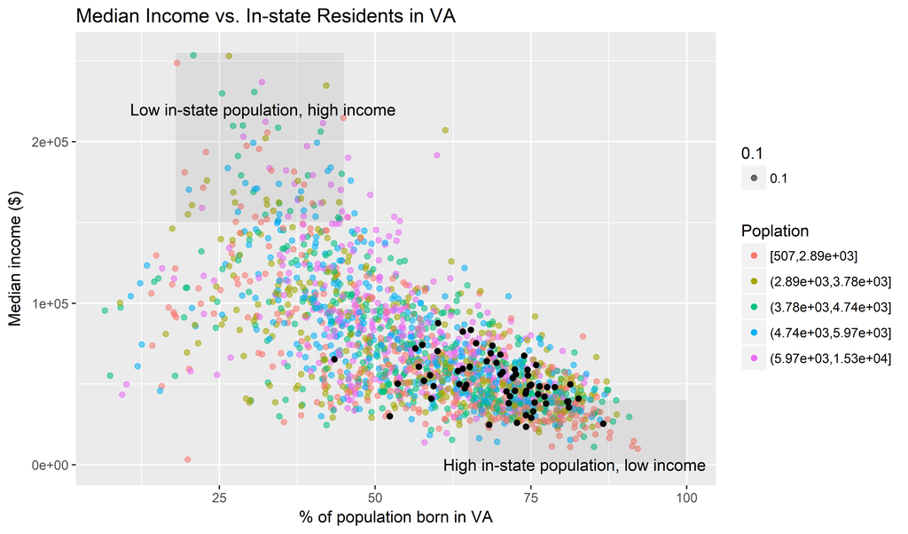

## Geographical Distribution in Roanoke, VA

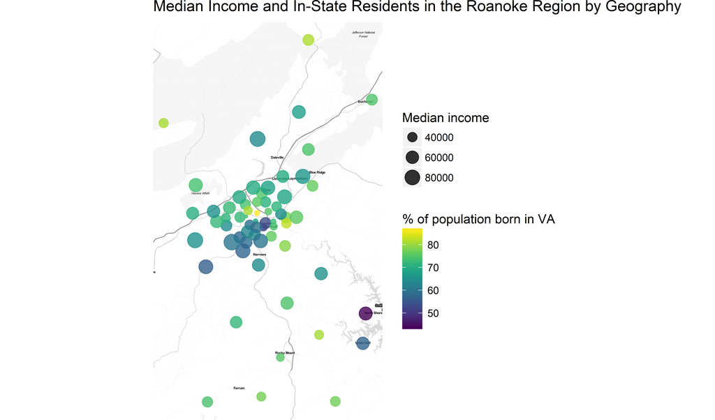

## Income and Population by County

Analysis of how the factors of median income and in-state population were related to the percentage of the working-age population was also conducted. The working-age was defined as between 25 and 59 years and this demographic was split into five groups of equal size. Median income, age, in-state population, and working-age population were all comparted by county. This graph confirms data in the graph of the geographic distribution of median incomes and reveals more detail in regard to the percentage of the working-age. Roanoke City had more locales with a high working-age population than the other counties in the same core-based statistical area. Interestingly, the plot for Roanoke City seems to contradict the correlation observed between higher in-state populations and lower median incomes by having locales with some of the lowest in-state populations and lowest incomes among the locales in the region. This trend may be related to the fact that Roanoke City is by far the most urban of the areas listed in this graph.

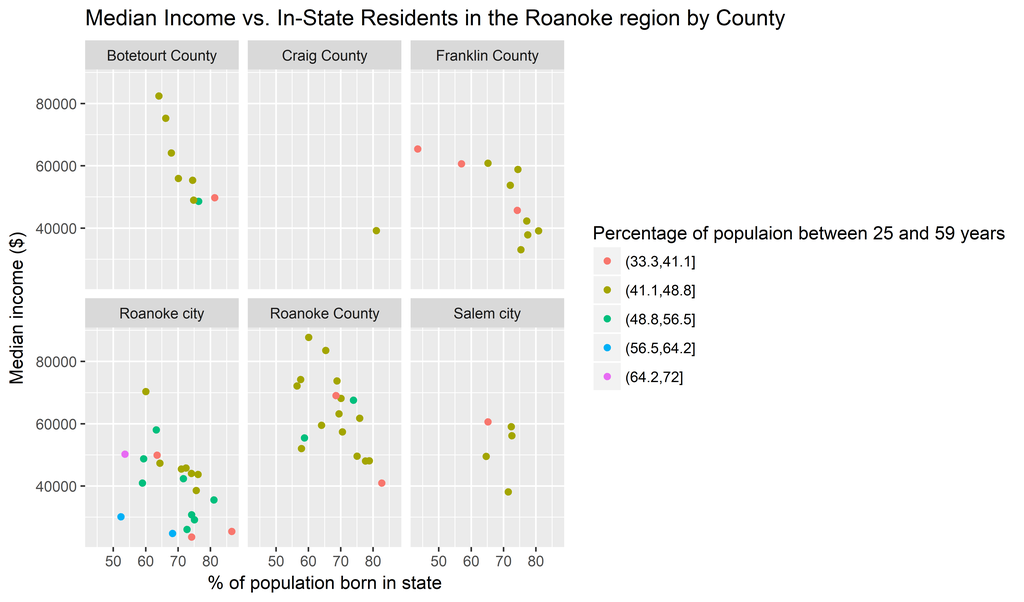

## Conlcusion

The information in this analysis supports the conclusion that high income among residents is correlated with lower percentages of in-state populations in Virginia. This conclusion would suggest that residents with high income from other states would migrate to Virginia, causing locales with low in-state populations to have higher median incomes. Residents born in Virginia with high incomes might also emigrate to other states, causing their native locales to have low median incomes. It is very likely that some locales do not receive immigration of wealthy out of state residents but still experience emigration of wealthy native residents, resulting in a high in-state population and a low median income in some locales and high median income and low in-state populations in others. This data also shows that the Roanoke region has a high in-state population and low income compared to some locales, but is typical for much of Virginia. Close analysis reveals that urban locales within the Roanoke region tend to have the lowest percentage of in-state residents, yet also have the lowest incomes as well as the highest percentage of working-age residents.